# Phase 1 - scRNA-seq QC and Preprocessing

2026-04-06

## Goal

This document implements **Phase 1** of the project workflow using the same logic as **Tutorial 10**:

- load 10X scRNA-seq data from `/Data/`
- inspect matrix dimensions and sparsity
- create a Seurat object
- calculate mitochondrial percentage
- visualize QC metrics
- choose filtering thresholds
- filter low-quality cells

> This file is written so you can use it directly in your project and later add your own explanations/decision checkpoint text.

## 1. Setup

```r
library(Seurat)
library(Matrix)
library(tidyverse)
library(patchwork)

knitr::opts_chunk$set(
  echo = TRUE,
  warning = FALSE,
  message = FALSE,
  fig.width = 8,
  fig.height = 5
)

# Define and create plots output folder
PLOTS_DIR <- "plots/phase1"
dir.create(PLOTS_DIR, showWarnings = FALSE, recursive = TRUE)
```

## 2. User-defined parameters

Edit these values after inspecting the QC plots.

```r
# Root folder containing the dataset
DATA_ROOT <- "Data/"

# Seurat project name
PROJECT_NAME <- "COVID_PBMC"

# QC thresholds (initial defaults; adjust after inspection)
MIN_FEATURES   <- 500
MAX_FEATURES   <- 6000
MIN_COUNTS     <- 1000   # remove cells with too few UMIs (likely empty droplets)
MAX_COUNTS     <- 40000  # remove cells with too many UMIs (likely doublets)
MAX_PERCENT_MT <- 20

# Optional: minimum number of cells expressing a gene to keep the gene at object creation
MIN_CELLS_PER_GENE <- 3

# (PLOTS_DIR already defined in setup chunk above)
```

## 3. Locate and load the 10X data

The 10X directory for GSE149689 is set explicitly below. A valid 10X directory must contain:

- `matrix.mtx` or `matrix.mtx.gz`
- `barcodes.tsv` or `barcodes.tsv.gz`
- `features.tsv` / `genes.tsv` (or gzipped versions)

```r
TENX_DIR <- "Data/GSE149689"
cat("Using 10X directory:\n", TENX_DIR, "\n")
```

```
## Using 10X directory:
##  Data/GSE149689
```

```r
counts <- Read10X(data.dir = TENX_DIR)

cat("Preview of the count matrix:\n")
```

```
## Preview of the count matrix:
```

```r
counts[1:min(10, nrow(counts)), 1:min(3, ncol(counts))]
```

```
## 10 x 3 sparse Matrix of class "dgCMatrix"
##             AAACCCAAGGGCAATC-1 AAACCCAAGGTGCCAA-1 AAACCCACAAGAATGT-1
## MIR1302-2HG                  .                  .                  .
## FAM138A                      .                  .                  .
## OR4F5                        .                  .                  .
## AL627309.1                   .                  .                  .
## AL627309.3                   .                  .                  .
## AL627309.2                   .                  .                  .
## AL627309.4                   .                  .                  .
## AL732372.1                   .                  .                  .
## OR4F29                       .                  .                  .
## AC114498.1                   .                  .                  .
```

## 4. Inspect matrix dimensions and sparsity

```r
total_entries <- as.numeric(nrow(counts)) * as.numeric(ncol(counts))
nonzero_entries <- length(counts@x)
sparsity_pct <- 100 * (1 - nonzero_entries / total_entries)
avg_genes_per_cell <- mean(Matrix::colSums(counts > 0))

cat("Matrix dimensions:\n")
```

```
## Matrix dimensions:
```

```r
cat("  Genes (rows): ", nrow(counts), "\n", sep = "")
```

```
##   Genes (rows): 33538
```

```r
cat("  Cells (columns): ", ncol(counts), "\n", sep = "")
```

```
##   Cells (columns): 85144
```

```r
cat("  Total entries: ", format(total_entries, big.mark = ","), "\n", sep = "")
```

```
##   Total entries: 2,855,559,472
```

```r
cat("  Non-zero entries: ", format(nonzero_entries, big.mark = ","), "\n", sep = "")
```

```
##   Non-zero entries: 127,119,627
```

```r
cat("  Sparsity: ", round(sparsity_pct, 2), "%\n", sep = "")
```

```
##   Sparsity: 95.55%
```

```r
cat("  Average genes per cell: ", round(avg_genes_per_cell, 1), "\n", sep = "")
```

```
##   Average genes per cell: 1493
```

## 5. Genes detected per cell

```r
genes_per_cell <- Matrix::colSums(counts > 0)
summary(genes_per_cell)
```

```
##    Min. 1st Qu.  Median    Mean 3rd Qu.    Max.
##       8     452    1522    1493    2084    8212
```

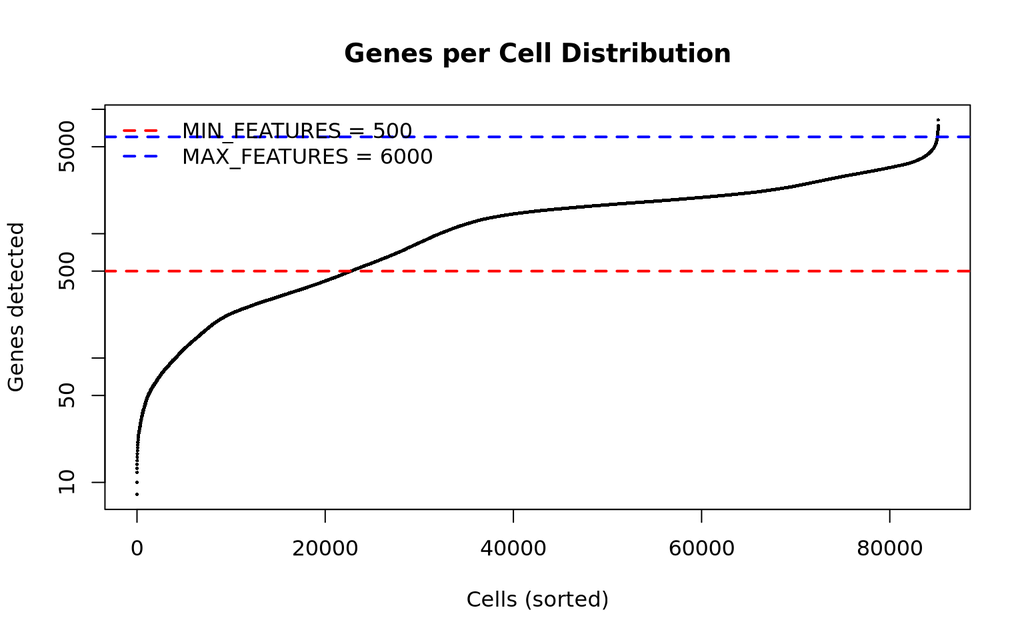

Genes detected per cell (sorted, log scale)

```r
plot(
  sort(genes_per_cell),
  xlab = "Cells (sorted)",
  ylab = "Genes detected",
  log = "y",
  main = "Genes per Cell Distribution",
  pch = 16,
  cex = 0.35
)

abline(h = MIN_FEATURES, col = "red", lwd = 2, lty = 2)
abline(h = MAX_FEATURES, col = "blue", lwd = 2, lty = 2)
legend(
  "topleft",
  legend = c(
    paste("MIN_FEATURES =", MIN_FEATURES),
    paste("MAX_FEATURES =", MAX_FEATURES)
  ),
  col = c("red", "blue"),
  lty = 2,
  lwd = 2,
  bty = "n"
)
```

```r
# Save plot
p_genes <- recordPlot()
png(file.path(PLOTS_DIR, "phase1_step05_genes_per_cell.png"), width = 900, height = 550)
replayPlot(p_genes)
dev.off()
```

## 6. Create Seurat object

```r
seurat <- CreateSeuratObject(
  counts = counts,
  project = PROJECT_NAME,
  min.cells = MIN_CELLS_PER_GENE
)

cat("Seurat object created.\n")
```

```
## Seurat object created.
```

```r
cat("  Cells:", ncol(seurat), "\n")
```

```
##   Cells: 85144
```

```r
cat("  Genes:", nrow(seurat), "\n")
```

```
##   Genes: 23335
```

## 7. Add mitochondrial QC metric

```r
seurat[["percent.mt"]] <- PercentageFeatureSet(seurat, pattern = "^MT-")

summary(seurat$percent.mt)
```

```
##    Min. 1st Qu.  Median    Mean 3rd Qu.    Max.
##   0.000   5.823   8.104  17.538  14.800  99.813
```

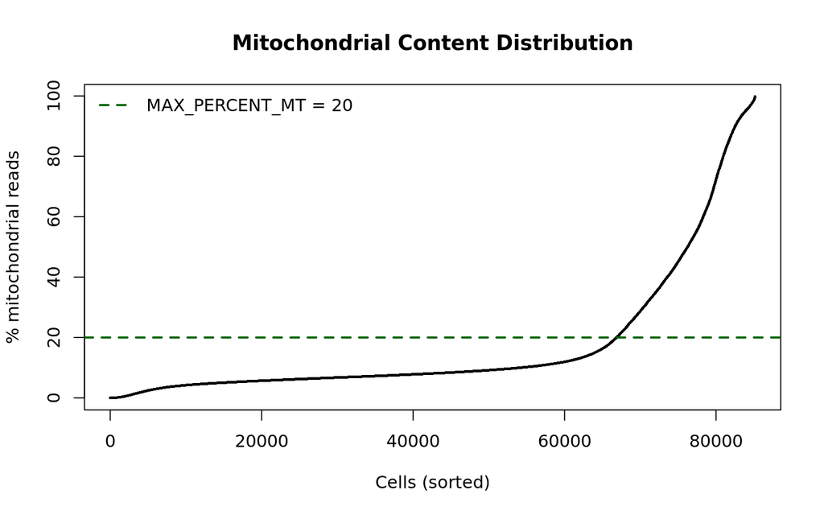

Mitochondrial percentage per cell (sorted)

```r
plot(
  sort(seurat$percent.mt),
  xlab = "Cells (sorted)",
  ylab = "% mitochondrial reads",
  main = "Mitochondrial Content Distribution",
  pch = 16,
  cex = 0.35
)

abline(h = MAX_PERCENT_MT, col = "darkgreen", lwd = 2, lty = 2)
legend(
  "topleft",
  legend = paste("MAX_PERCENT_MT =", MAX_PERCENT_MT),
  col = "darkgreen",
  lty = 2,
  lwd = 2,
  bty = "n"
)
```

```r
# Save plot
p_mito <- recordPlot()
png(file.path(PLOTS_DIR, "phase1_step07_mito_distribution.png"), width = 900, height = 550)
replayPlot(p_mito)
dev.off()
```

## 8. Visualize QC metrics

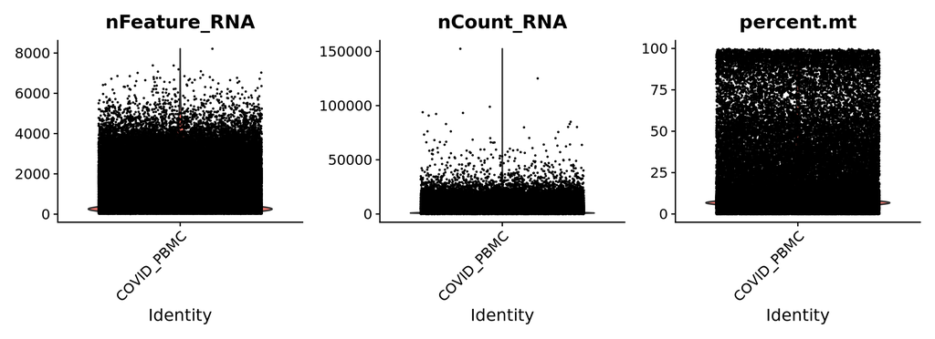

```r
p_vln_qc <- VlnPlot(
  seurat,
  features = c("nFeature_RNA", "nCount_RNA", "percent.mt"),
  ncol = 3,
  pt.size = 0.1
) + NoLegend()
p_vln_qc
```

```r
ggsave(file.path(PLOTS_DIR, "phase1_step08_violin_qc_metrics.png"),
       plot = p_vln_qc, width = 11, height = 4, dpi = 150)
```

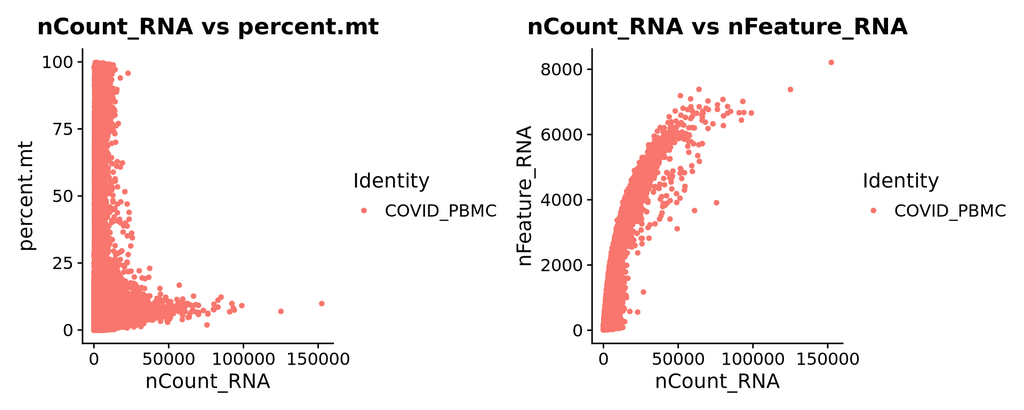

```r
p1 <- FeatureScatter(seurat, feature1 = "nCount_RNA", feature2 = "percent.mt") +
  ggtitle("nCount_RNA vs percent.mt")

p2 <- FeatureScatter(seurat, feature1 = "nCount_RNA", feature2 = "nFeature_RNA") +
  ggtitle("nCount_RNA vs nFeature_RNA")

p_scatter_qc <- p1 + p2
p_scatter_qc
```

```r
ggsave(file.path(PLOTS_DIR, "phase1_step08_scatter_qc_metrics.png"),
       plot = p_scatter_qc, width = 10, height = 4, dpi = 150)
```

## 9. Summarize filtering rules before applying them

```r
qc_summary_before <- tibble(
  metric = c("cells_total",
             paste0("nFeature_RNA <= ", MIN_FEATURES),
             paste0("nFeature_RNA >= ", MAX_FEATURES),
             paste0("nCount_RNA <= ",   MIN_COUNTS),
             paste0("nCount_RNA >= ",   MAX_COUNTS),
             paste0("percent.mt >= ",   MAX_PERCENT_MT)),
  value = c(
    ncol(seurat),
    sum(seurat$nFeature_RNA <= MIN_FEATURES),
    sum(seurat$nFeature_RNA >= MAX_FEATURES),
    sum(seurat$nCount_RNA   <= MIN_COUNTS),
    sum(seurat$nCount_RNA   >= MAX_COUNTS),
    sum(seurat$percent.mt   >= MAX_PERCENT_MT)
  )
)

qc_summary_before
```

```
## # A tibble: 6 × 2
##   metric               value
##   <chr>                <dbl>
## 1 cells_total          85144
## 2 nFeature_RNA <= 500  22774
## 3 nFeature_RNA >= 6000    77
## 4 nCount_RNA <= 1000   13959
## 5 nCount_RNA >= 40000    161
## 6 percent.mt >= 20     18282
```

## 10. Filter cells

```r
seurat_filtered <- subset(
  seurat,
  subset = nFeature_RNA > MIN_FEATURES &
           nFeature_RNA < MAX_FEATURES &
           nCount_RNA   > MIN_COUNTS   &
           nCount_RNA   < MAX_COUNTS   &
           percent.mt   < MAX_PERCENT_MT
)

cat("Cells before filtering:", ncol(seurat), "\n")
```

```
## Cells before filtering: 85144
```

```r
cat("Cells after filtering:", ncol(seurat_filtered), "\n")
```

```
## Cells after filtering: 55548
```

```r
cat("Cells removed:", ncol(seurat) - ncol(seurat_filtered), "\n")
```

```
## Cells removed: 29596
```

## 11. Compare QC metrics before vs after filtering

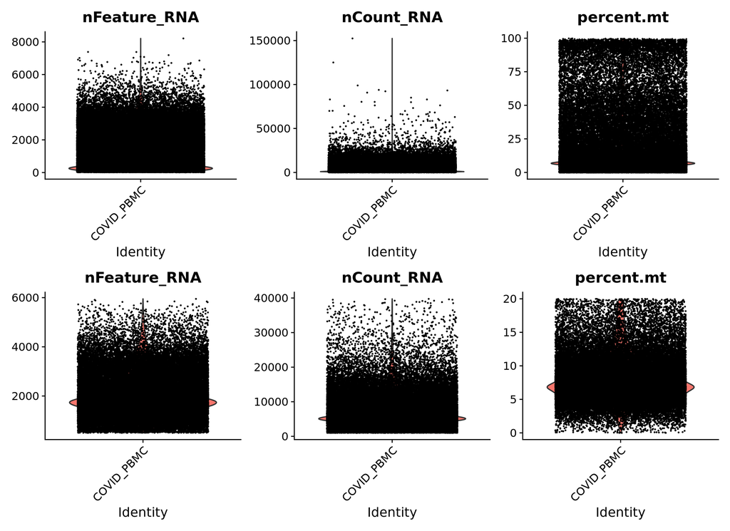

```r
p_before <- VlnPlot(
  seurat,
  features = c("nFeature_RNA", "nCount_RNA", "percent.mt"),
  ncol = 3,
  pt.size = 0.1
) + plot_annotation(title = "Before filtering")

p_after <- VlnPlot(
  seurat_filtered,
  features = c("nFeature_RNA", "nCount_RNA", "percent.mt"),
  ncol = 3,
  pt.size = 0.1
) + plot_annotation(title = "After filtering")

p_compare <- p_before / p_after
p_compare
```

```r
ggsave(file.path(PLOTS_DIR, "phase1_step11_before_after_filtering.png"),
       plot = p_compare, width = 11, height = 8, dpi = 150)
```

```r
qc_summary_after <- tibble(
  metric = c("cells_remaining",
             "median_nFeature_RNA",
             "median_nCount_RNA",
             "median_percent.mt"),
  value = c(
    ncol(seurat_filtered),
    median(seurat_filtered$nFeature_RNA),
    median(seurat_filtered$nCount_RNA),
    median(seurat_filtered$percent.mt)
  )
)

qc_summary_after
```

```
## # A tibble: 4 × 2
##   metric                 value
##   <chr>                  <dbl>
## 1 cells_remaining     55548
## 2 median_nFeature_RNA  1872
## 3 median_nCount_RNA    5845
## 4 median_percent.mt       7.32
```

## 12. Save the filtered object

```r
saveRDS(seurat_filtered, file = file.path(DATA_ROOT, "phase1_seurat_filtered.rds"))
cat("Saved filtered Seurat object to:\n", file.path(DATA_ROOT, "phase1_seurat_filtered.rds"), "\n")
```

```
## Saved filtered Seurat object to:
##  Data//phase1_seurat_filtered.rds
```

## 13. Decision checkpoint 1

**Decision:** I filtered cells using thresholds on nFeature_RNA, nCount_RNA, and percent.mt.

**What I chose:**

| Threshold | Value | Reason |
| --- | --- | --- |
| MIN_FEATURES | 500 | Sits just above the empty-droplet cliff in the genes-per-cell plot |
| MAX_FEATURES | 6,000 | Catches the small doublet spike at the far right of the distribution |
| MIN_COUNTS | 1,000 | Removes weak-capture droplets independently of gene count |
| MAX_COUNTS | 40,000 | Removes high-UMI doublets |
| MAX_PERCENT_MT | 20% | Preserves the large flat healthy region, removes the exponential damage tail |

**Outcome:**

- Cells before: 85,144
- Cells after: **55,548** (29,596 removed, 34.8%)
- Post-filtering medians: 1,872 genes/cell, 5,845 UMIs/cell, 7.3% mito

**Why these thresholds:**  
All five thresholds were chosen by visually inspecting the QC plots (steps 5, 7, 8). The genes-per-cell distribution clearly showed a dropout cliff below 500 and a doublet spike above 6,000. The mitochondrial distribution showed a flat healthy region up to ~15% followed by a sharp exponential rise — 20% sits at the start of that rise and is a standard cutoff in the literature. The nCount thresholds add an independent check: 1,000 removes very weak droplets that passed the gene filter, and 40,000 removes high-UMI doublets.

**Largest sources of removed cells:** - 22,774 cells (26.7%) — too few genes (empty droplets / ambient RNA) - 18,282 cells (21.5%) — too high mitochondrial content (damaged cells, consistent with severe COVID samples) - 13,959 cells (16.4%) — too few UMIs (weak capture) - 238 cells (0.3%) — doublet candidates (very few, consistent with a well-run experiment)

**Alternatives considered:**  
Adaptive thresholds based on median absolute deviation (MAD) could be used instead of fixed values. Dedicated doublet-detection tools (e.g. DoubletFinder) could replace the upper gene/count cutoffs. For a final version, these would be worth applying, especially for the doublet filter.

## 14. Next step

After Phase 1, continue with:

- `SCTransform()`
- `RunPCA()`
- `ElbowPlot()`
- `RunUMAP()` / `RunTSNE()`
- `FindNeighbors()` and `FindClusters()`

That corresponds to the next part of Tutorial 10 and your project roadmap.